# Repeated measures designs

Andy Field, University of Sussex

Links: [bsky.app](https://bsky.app/profile/profandyfield.bsky.social) | [youtube.com](https://www.youtube.com/user/ProfAndyField) | discoveringstatistics.com | discovr.rocks | statisticsadventure.com

## About this version

This is a plain-text version of the lecture slides. Each slide starts with a heading such as “Slide 5”, and the numbers match the slide numbers shown in the lecture. Content that appeared one piece at a time, in columns or in tabs is shown in reading order. Videos and interactive apps are given as links.

## Slide 2

Video clip: [space opening scene](https://profandyfield.github.io/statistics_lectures/shared_media/video/space_opening_scene.mp4)

## Slide 3

Video clip: [daze intro 01](https://profandyfield.github.io/statistics_lectures/shared_media/video/daze_intro_01.mp4)

## Slide 4

Video clip: [daze intro 02](https://profandyfield.github.io/statistics_lectures/shared_media/video/daze_intro_02.mp4)

## Slide 5

Video clip: [transmission 01](https://profandyfield.github.io/statistics_lectures/shared_media/video/transmission_01.mp4)

## Slide 6

Video clip: [daze intro 03](https://profandyfield.github.io/statistics_lectures/shared_media/video/daze_intro_03.mp4)

## Slide 7

Video clip: [daze intro 04](https://profandyfield.github.io/statistics_lectures/shared_media/video/daze_intro_04.mp4)

## Slide 8

Video clip: [space hippo](https://profandyfield.github.io/statistics_lectures/shared_media/video/space_hippo.mp4)

## Slide 9


## Slide 10

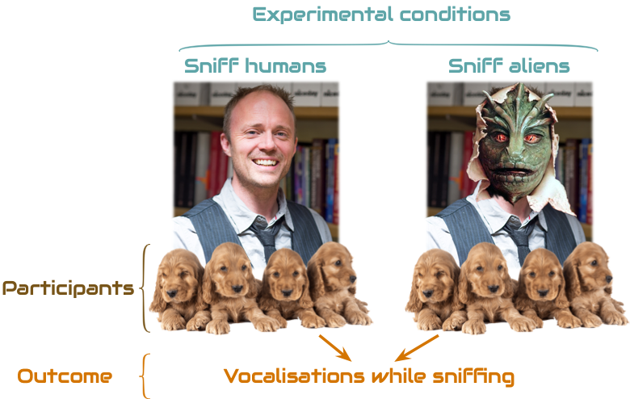

- **Systematic variance**: created by our manipulation
- **Unsystematic variance**: variance created by unknown factors

## Slide 11: Benefits of repeated measures designs

- Sensitivity
  - Unsystematic variance is reduced
  - More sensitive to experimental effects
- Economy
  - Less participants are needed
  - But, be careful of fatigue

## Slide 12: Can puppies sniff out aliens?

- Outcome = vocalizations during 1 min sniffing (`vocalizations`)
- Predictor: type of entity being sniffed (`entity`)
  - Alien (not in humanoid form)
  - Human (control for alien vs human)
  - Mannequin (control for humanoid form)
  - Shapeshifter (alien in humanoid form)
- `dog_name` indicates the name of the dog (*N* = 8)

> **Note: Statis-tip**

> This is a **one-way repeated measures design**.

## Slide 13: The data

|  | dog_name | Alien | Human | Mannequin | Shapeshifter | Mean | Variance |
| --- | --- | --- | --- | --- | --- | --- | --- |
|  | Milton | 8 | 7 | 1 | 6 | 5.50 | 7.25 |
|  | Woofy | 9 | 5 | 2 | 5 | 5.25 | 6.19 |
|  | Ramsey | 6 | 2 | 3 | 8 | 4.75 | 5.69 |
|  | Mr. Snifficus III | 5 | 3 | 1 | 9 | 4.50 | 8.75 |
|  | Willock | 8 | 4 | 5 | 8 | 6.25 | 3.19 |
|  | The Venerable Dr. Waggy | 7 | 5 | 6 | 7 | 6.25 | 0.69 |
|  | Lord Scenticle | 10 | 2 | 7 | 2 | 5.25 | 11.69 |
|  | Professor Nose | 12 | 6 | 8 | 1 | 6.75 | 15.69 |
| **Mean** | — | 8.12 | 4.25 | 4.12 | 5.75 | — | — |

## Slide 14: The data in R

Table 2: Data for the sniffer dog example

|  | dog_name | entity | vocalizations |
| --- | --- | --- | --- |
| 1 | Milton | Alien | 8 |
| 2 | Milton | Human | 7 |
| 3 | Milton | Mannequin | 1 |
| 4 | Milton | Shapeshifter | 6 |
| 5 | Woofy | Alien | 9 |
| 6 | Woofy | Human | 5 |
| 7 | Woofy | Mannequin | 2 |
| 8 | Woofy | Shapeshifter | 5 |
| 9 | Ramsey | Alien | 6 |
| 10 | Ramsey | Human | 2 |
| 11 | Ramsey | Mannequin | 3 |
| 12 | Ramsey | Shapeshifter | 8 |
| 13 | Mr. Snifficus III | Alien | 5 |
| 14 | Mr. Snifficus III | Human | 3 |
| 15 | Mr. Snifficus III | Mannequin | 1 |
| 16 | Mr. Snifficus III | Shapeshifter | 9 |
| 17 | Willock | Alien | 8 |
| 18 | Willock | Human | 4 |
| 19 | Willock | Mannequin | 5 |
| 20 | Willock | Shapeshifter | 8 |
| 21 | The Venerable Dr. Waggy | Alien | 7 |
| 22 | The Venerable Dr. Waggy | Human | 5 |
| 23 | The Venerable Dr. Waggy | Mannequin | 6 |
| 24 | The Venerable Dr. Waggy | Shapeshifter | 7 |
| 25 | Lord Scenticle | Alien | 10 |
| 26 | Lord Scenticle | Human | 2 |
| 27 | Lord Scenticle | Mannequin | 7 |
| 28 | Lord Scenticle | Shapeshifter | 2 |
| 29 | Professor Nose | Alien | 12 |
| 30 | Professor Nose | Human | 6 |
| 31 | Professor Nose | Mannequin | 8 |
| 32 | Professor Nose | Shapeshifter | 1 |

## Slide 15: Repeated measures and the linear model

To keep things simple, imagine a design where dogs sniff only aliens or humans (e.g., two conditions)

$$\begin{aligned} \text{vocalizations}_{i} & = b_{0} + b_{1}\text{entity}_{i} + \varepsilon_{i} \end{aligned}$$

| Entity sniffed | Dummy variable (entity) |
| --- | --- |
| Alien | 1 |
| Human | 0 |

> **Warning: The danger zone!**

> Same participants in all conditions
> - Scores across conditions correlate
> - Violates the assumption of independent residuals (think back to the lecture on bias)

## Slide 16: Repeated measures: hierrachical data structure

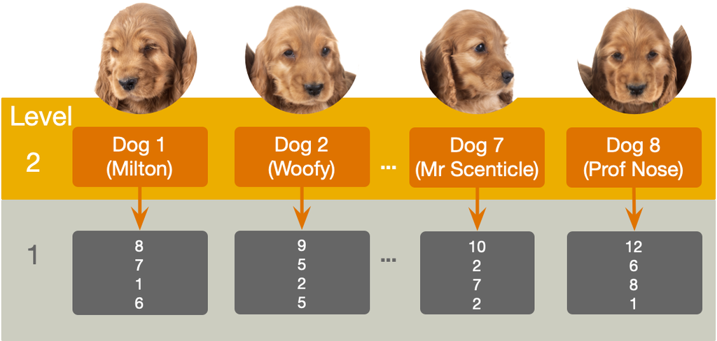

## Slide 17: Repeated measures and the linear model

Need to adjust the model to estimate this dependency

$$\begin{aligned} \text{vocalizations}_{ij} & = (\beta_{0} + u_{0j}) + (\beta_{1} + u_{1j})\text{entity}_{ij}+ \varepsilon_{ij} \\ & = \left[\beta_{0} + \beta_{1}\text{entity}_{ij}\right]+ \left[u_{0j} + u_{1j}\text{entity}_{ij} + \varepsilon_{ij}\right]\\ \end{aligned}$$

## Slide 18

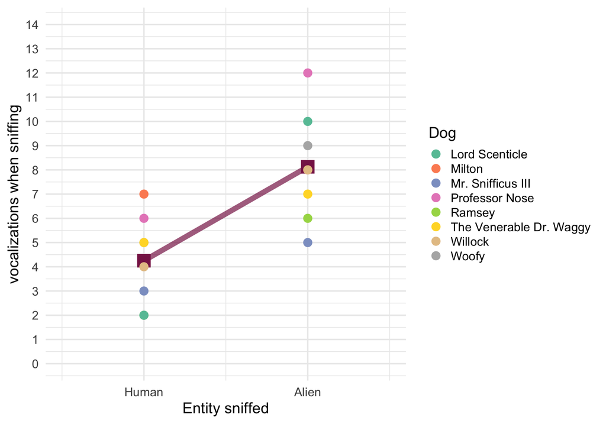

$$\begin{aligned} \text{vocalizations}_{ij} & = (\beta_{0} + u_{0j})+ \beta_{1}\text{entity}_{ij}+ \varepsilon_{ij} \end{aligned}$$

## Slide 19

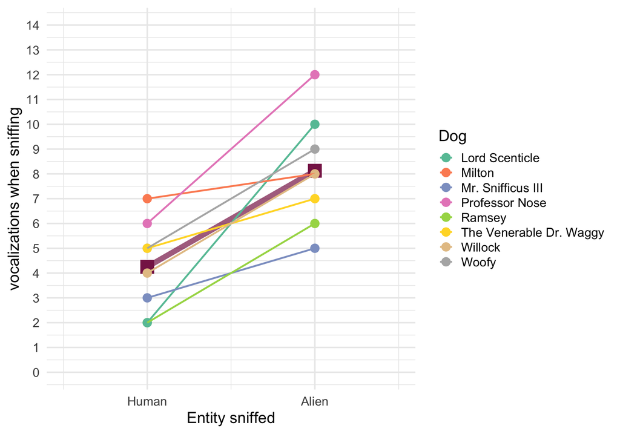

$$\begin{aligned} \text{vocalizations}_{ij} & = (\beta_{0} + u_{0j}) + (\beta_{1} + u_{1j})\text{entity}_{ij}+ \varepsilon_{ij} \end{aligned}$$

## Slide 20: Repeated measures and the linear model

Back to our actual design (with 4 conditions: Alien, Human, Mannequin, Shapeshifter)

- `entity` would be split into 3 dummy/contrast variables
- Let’s just use default dummy coding

| Entity sniffed | Dummy 1 (Alien vs. mannequin) | Dummy 2 (Shapeshifter vs. mannequin) | Dummy 3 (Human vs. mannequin) |
| --- | --- | --- | --- |
| Alien | 1 | 0 | 0 |
| Shapeshifter | 0 | 1 | 0 |
| Human | 0 | 0 | 1 |
| Mannequin | 0 | 0 | 0 |

## Slide 21

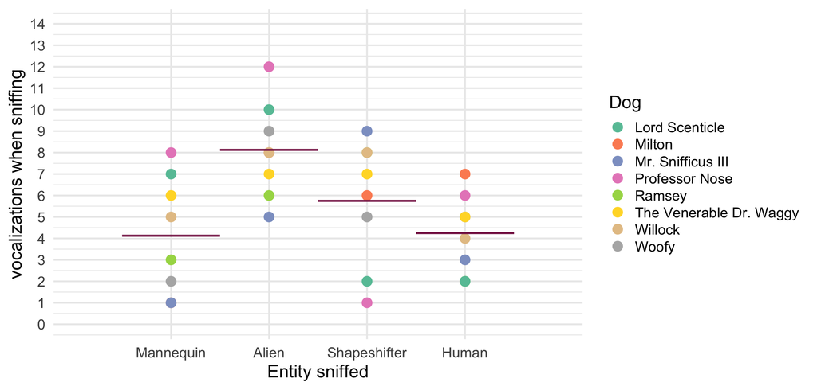

## Slide 22

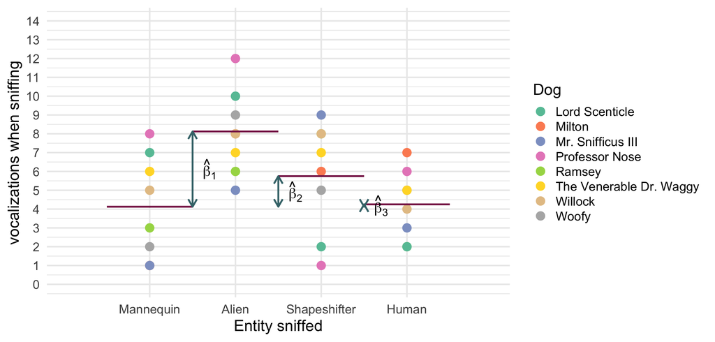

$$\begin{aligned} \text{vocalizations}_{ij} & = \left[\beta_{0} + \beta_{1}\text{alien vs. manq}_{ij} + \beta_{2}\text{shape vs. manq}_{ij} + \beta_{3}\text{human vs. manq}_{ij}\right] \\ &\quad + \left[u_{0j} + \varepsilon_{ij}\right] \\ \end{aligned}$$

## Slide 23

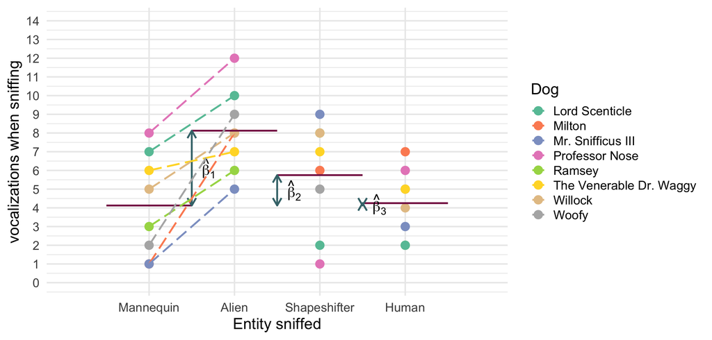

$$\begin{aligned} \text{vocalizations}_{ij} & = \left[\beta_{0} + \beta_{1}\text{alien vs. manq}_{ij} + \beta_{2}\text{shape vs. manq}_{ij} + \beta_{3}\text{human vs. manq}_{ij}\right] \\ &\quad + \left[u_{0j} + u_{1j}\text{alien vs. manq}_{ij} + \varepsilon_{ij}\right] \\ \end{aligned}$$

## Slide 24

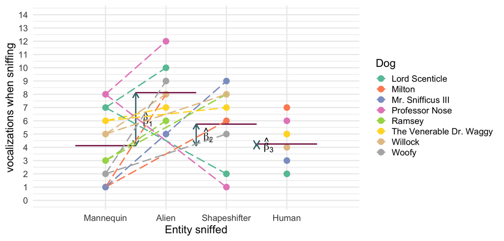

$$\begin{aligned} \text{vocalizations}_{ij} & = \left[\beta_{0} + \beta_{1}\text{alien vs. manq}_{ij} + \beta_{2}\text{shape vs. manq}_{ij} + \beta_{3}\text{human vs. manq}_{ij}\right] \\ &\quad + \left[u_{0j} + u_{1j}\text{alien vs. manq}_{ij} + u_{2j}\text{shape vs. manq}_{ij} + \varepsilon_{ij}\right] \\ \end{aligned}$$

## Slide 25

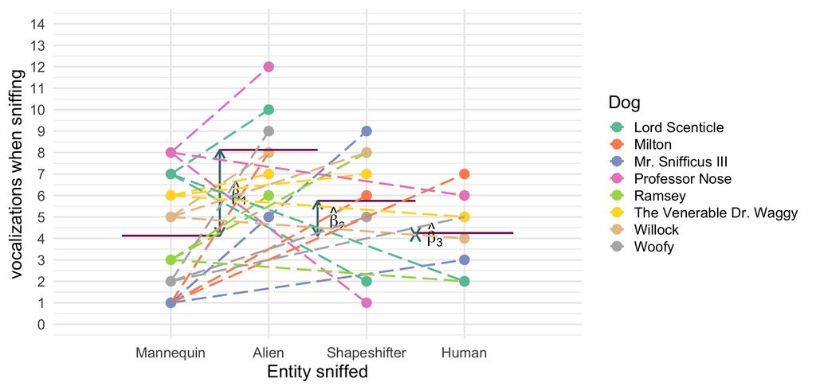

$$\begin{aligned} \text{vocalizations}_{ij} & = \left[\beta_{0} + \beta_{1}\text{alien vs. manq}_{ij} + \beta_{2}\text{shape vs. manq}_{ij} + \beta_{3}\text{human vs. manq}_{ij}\right] \\ &\quad + \left[u_{0j} + u_{1j}\text{alien vs. manq}_{ij} + u_{2j}\text{shape vs. manq}_{ij} + u_{3j}\text{human vs. manq}_{ij} + \varepsilon_{ij}\right] \\ \end{aligned}$$

## Slide 26: Approaches to repeated measures designs

### Historic: Repeated measures ANOVA (RM-ANOVA)

- Restricts the model in two (unrealistic) ways
  1. Assumes effects are equivalent across participants (the effect in participant 1 is the same as in participant 2)
  2. Errors have compound symmetry/sphericity
  - CS: The correlation between scores across conditions is the same
  - Sphericity: differences between scores in pairs of conditions have equal variances

### Multilevel modelling (MLM) approach

- Fewer restrictions: doesn’t require CS or sphericity
- Can include multiple hierarchical structures (e.g., observations within people, within clinics)
- In general, copes with missing values (RM-ANOVA doesn’t)
- Can be extended to categorical outcomes (RM-ANOVA cannot)
- Contrast coding is possible

## Slide 27: Fitting the model

- Use `glmmTMB::glmmTMB()`
  - A trickier but more flexible option
  - Manually set contrasts
  - Can get parameter estimates, diagnostic plots, and robust methods
- The `afex::aov_4()` function
  - Specify the repeated measures with `(rm_predictors|id_var)`
  - Automatically sets contrasts
  - Built in interaction plot with `afex_plot()`
  - But … no parameter estimates, limited diagnostic plots, or robust methods
  - See alternative tutorial

## Slide 28

## Slide 29: Load and Look

```r
sniff_tib |>
  group_by(entity) |>
  describe_distribution(select = "vocalizations") |>
  data_remove(c("Variable", "n_Missing")) |> # optional to remove redundant column
  display()
```

| entity | Mean | SD | IQR | Range | Skewness | Kurtosis | n |
| --- | --- | --- | --- | --- | --- | --- | --- |
| Alien | 8.12 | 2.23 | 3.50 | (5.00, 12.00) | 0.41 | 0.01 | 8 |
| Human | 4.25 | 1.83 | 3.50 | (2.00, 7.00) | 0.07 | -1.22 | 8 |
| Mannequin | 4.12 | 2.75 | 5.50 | (1.00, 8.00) | 0.16 | -1.78 | 8 |
| Shapeshifter | 5.75 | 2.92 | 5.25 | (1.00, 9.00) | -0.78 | -0.76 | 8 |

## Slide 30: Visualize

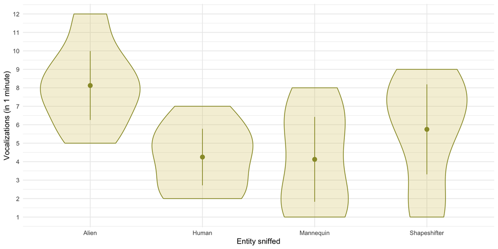

## Slide 31: Fit the model: Contrasts

If the dog training has been successful then we’d expect sniffer dogs to make more vocalizations when sniffing alien entities than non alien-entities.

- **Contrast 1**: {alien, shapeshifter} vs. {human, mannequin}

We have two ‘chunks’ in contrast 1 that would then need to be decomposed:

- **Contrast 2**: {alien} vs. {shapeshifter}
- **Contrast 3**: {human} vs. {mannequin}

Using the rules for contrast coding we’d get the codes in Table 4:

Table 4: Contrast coding for the entity variable

| Group | Contrast 1 | Contrast 2 | Contrast 3 |
| --- | --- | --- | --- |
| Alien | 1/2 | 1/2 | 0 |
| Human | -1/2 | 0 | 1/2 |
| Mannequin | -1/2 | 0 | -1/2 |
| Shapeshifter | 1/2 | -1/2 | 0 |

## Slide 32: Fitting the model

```r
aliens_vs_non = c(1/2, -1/2, -1/2, 1/2)
alien_vs_shape = c(1/2, 0, 0, -1/2)
human_vs_manquin = c(0, 1/2, -1/2, 0)

contrasts(sniff_tib$entity) <- cbind(aliens_vs_non,
                                     alien_vs_shape,
                                     human_vs_manquin)

sniff_mlm <- glmmTMB::glmmTMB(vocalizations ~ entity + (1|dog_name),
                              data = sniff_tib)
```

## Slide 33: Evaluate the model

```r
test_lrt(sniff_mlm) |>
  display()
```

Likelihood-Ratio-Test (LRT) for Model Comparison

| Name | df | df_diff | Chi2 | p |
| --- | --- | --- | --- | --- |
| Null model | 3 |  |  |  |
| Full model | 6 | 3 | 12.69 | 0.005 |

> **Important: ReportR**

> The entity sniffed had a significant effect on the number of vocalizations by sniffer dogs, $\chi^2$(3) = 12.69, *p* = 0.005.

## Slide 34: Evaluate the model

```r
model_performance(sniff_mlm) |>
  display()
```

```
Random effect variances not available. Returned R2 does not account for random effects.
```

| AIC | AICc | BIC | R2 (cond.) | R2 (marg.) | RMSE | Sigma |
| --- | --- | --- | --- | --- | --- | --- |
| 156.4 | 159.8 | 165.2 |  | 0.33 | 2.31 | 2.31 |

## Slide 35: Evaluate assumptions

```r
check_model(sniff_mlm)
```

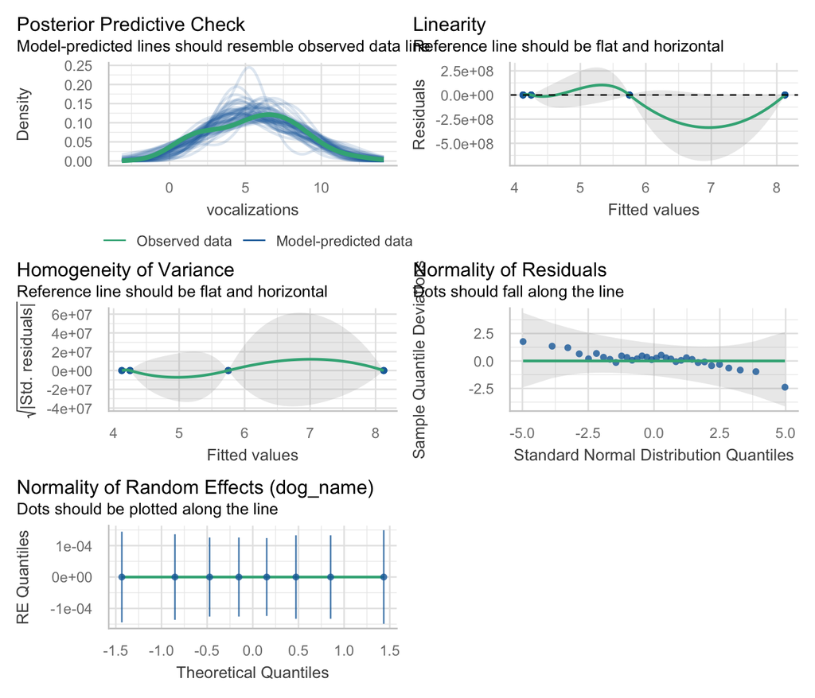

## Slide 36: Interpret parameter estimates, CIs and tests

```r
model_parameters(sniff_mlm, effects = "fixed") |>
  display()
```

Fixed Effects

| Parameter | Coefficient | SE | 95% CI | z | p |
| --- | --- | --- | --- | --- | --- |
| (Intercept) | 5.56 | 0.41 | (4.76, 6.36) | 13.62 | < .001 |
| entityaliens vs non | 2.75 | 0.82 | (1.15, 4.35) | 3.37 | < .001 |
| entityalien vs shape | 2.38 | 1.15 | (0.11, 4.64) | 2.06 | 0.040 |
| entityhuman vs manquin | 0.12 | 1.15 | (-2.14, 2.39) | 0.11 | 0.914 |

> **Important: ReportR**

> Contrasts revealed that vocalizations were significantly higher when sniffing aliens compared to non-aliens, $\hat{b}$ = 2.75 (1.15, 4.35), *z* = 3.37, *p* < 0.001), and when sniffing an alien compared to a shapeshifter, $\hat{b}$ = 2.38 (0.11, 4.64), *z* = 2.06, *p* = 0.040 but not when sniffing a human compared to a mannequin, $\hat{b}$ = 0.12 (-2.14, 2.39), *z* = 0.11, *p* = 0.914).

## Slide 37

Audio clip: [spaceship interior](https://profandyfield.github.io/statistics_lectures/shared_media/audio/spaceship_interior.mp3)

## Slide 38

Video clip: [daze middle 01](https://profandyfield.github.io/statistics_lectures/shared_media/video/daze_middle_01.mp4)

## Slide 39

Video clip: [transmission 02 lme](https://profandyfield.github.io/statistics_lectures/shared_media/video/transmission_02_lme.mp4)

## Slide 40

Video clip: [daze middle 02](https://profandyfield.github.io/statistics_lectures/shared_media/video/daze_middle_02.mp4)

## Slide 41 (new section): Scenting a victory … factorial repeated measures designs

## Slide 42: Can scents distract the sniffer dogs?

- 50 sniffer dogs
  - Participated in all conditions
  - Sniffed 9 different ‘things’
- Predictor: `entity`
  - **Human**: the dog sniffs a human
  - **Shapeshifter** the dog sniffs an alien in humanoid form
  - **Alien** the dog sniffs an alien in lizard form
- Predictor: `scent_mask`
  - The entity had no masking scent (**none**)
  - The entity was smeared with **human** pheromones
  - The entity was smeared with **fox** pheromones
- Outcome: The number of `vocalizations` during each 1 minute sniff

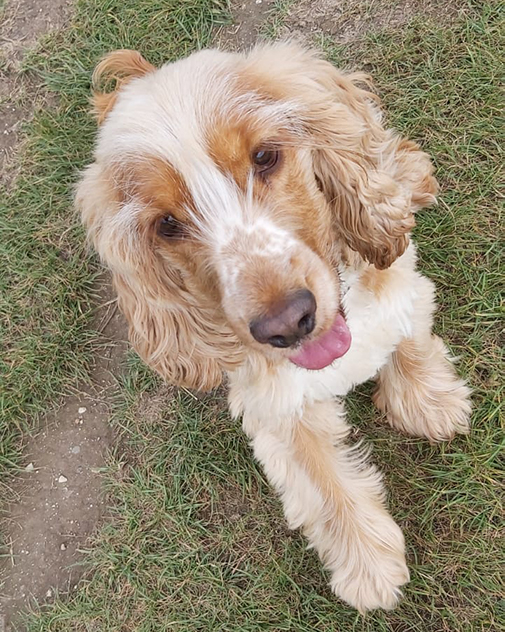

> **Note: Statis-tip**

> This is a **two-way repeated measures design**.

## Slide 43: The model

- Let’s simplify things by ignoring the fact that `entity` and `scent_mask` will be represented by two dummy variables each (and the interaction by 4!)
- We can model individual differences in all parameters

$$\begin{aligned} \text{vocalizations}_{ij} &= \left[\beta_{0} + \beta_{1}\text{entity}_{ij} + \beta_{2}\text{scent}_{ij} + \beta_{3}(\text{entity}_{ij}\times\text{scent}_{ij})\right] + \\ &\quad \left[u_{0j} + u_{1j}\text{entity}_{ij} + u_{2j}\text{scent}_{ij} + u_{3j}(\text{entity}_{ij}\times\text{scent}_{ij}) + \varepsilon_{ij}\right]\\ \end{aligned}$$

- This model will be too complex to fit
- The simplest version of the repeated measures model instead treats the effects of predictor variables as fixed, but acknowledges that dogs, overall, will vary in their vocalizations:

$$\begin{aligned} \text{vocalizations}_{ij} & = \left[\beta_{0} + \beta_{1}\text{entity}_{ij} + \beta_{2}\text{scent}_{ij} + \beta_{3}(\text{entity}_{ij}\times\text{scent}_{ij})\right] +\\ &\quad \left[u_{0j} + \varepsilon_{ij}\right]\\ u_{0j} &\sim N(0, \sigma^{2}_{\mu_0}) \end{aligned}$$

## Slide 44: Load and Look

Table 7: Data for the scent masking example (first 50 of 450 rows)

|  | dog_id | entity | scent_mask | vocalizations |
| --- | --- | --- | --- | --- |
| 1 | 56f9p | Alien | Fox | 7 |
| 2 | 56f9p | Alien | Human | 9 |
| 3 | 56f9p | Alien | None | 8 |
| 4 | 56f9p | Shapeshifter | Fox | 11 |
| 5 | 56f9p | Shapeshifter | Human | 6 |
| 6 | 56f9p | Shapeshifter | None | 8 |
| 7 | 56f9p | Human | Fox | 3 |
| 8 | 56f9p | Human | Human | 3 |
| 9 | 56f9p | Human | None | 3 |
| 10 | 2m89y | Alien | Fox | 8 |
| 11 | 2m89y | Alien | Human | 8 |
| 12 | 2m89y | Alien | None | 10 |
| 13 | 2m89y | Shapeshifter | Fox | 10 |
| 14 | 2m89y | Shapeshifter | Human | 7 |
| 15 | 2m89y | Shapeshifter | None | 10 |
| 16 | 2m89y | Human | Fox | 6 |
| 17 | 2m89y | Human | Human | 4 |
| 18 | 2m89y | Human | None | 3 |
| 19 | 682h3 | Alien | Fox | 13 |
| 20 | 682h3 | Alien | Human | 5 |
| 21 | 682h3 | Alien | None | 5 |
| 22 | 682h3 | Shapeshifter | Fox | 4 |
| 23 | 682h3 | Shapeshifter | Human | 4 |
| 24 | 682h3 | Shapeshifter | None | 7 |
| 25 | 682h3 | Human | Fox | 8 |
| 26 | 682h3 | Human | Human | 2 |
| 27 | 682h3 | Human | None | 2 |
| 28 | 7o1d2 | Alien | Fox | 7 |
| 29 | 7o1d2 | Alien | Human | 10 |
| 30 | 7o1d2 | Alien | None | 12 |
| 31 | 7o1d2 | Shapeshifter | Fox | 9 |
| 32 | 7o1d2 | Shapeshifter | Human | 6 |
| 33 | 7o1d2 | Shapeshifter | None | 12 |
| 34 | 7o1d2 | Human | Fox | 8 |
| 35 | 7o1d2 | Human | Human | 2 |
| 36 | 7o1d2 | Human | None | 2 |
| 37 | 2k3vo | Alien | Fox | 11 |
| 38 | 2k3vo | Alien | Human | 9 |
| 39 | 2k3vo | Alien | None | 11 |
| 40 | 2k3vo | Shapeshifter | Fox | 10 |
| 41 | 2k3vo | Shapeshifter | Human | 9 |
| 42 | 2k3vo | Shapeshifter | None | 7 |
| 43 | 2k3vo | Human | Fox | 7 |
| 44 | 2k3vo | Human | Human | 5 |
| 45 | 2k3vo | Human | None | 2 |
| 46 | ik011 | Alien | Fox | 6 |
| 47 | ik011 | Alien | Human | 9 |
| 48 | ik011 | Alien | None | 11 |
| 49 | ik011 | Shapeshifter | Fox | 8 |
| 50 | ik011 | Shapeshifter | Human | 9 |

## Slide 45: Load and Look

```r
scent_tib |>
  group_by(entity, scent_mask) |>
  describe_distribution(select = "vocalizations")  |>
  data_remove(c("Variable", "n_Missing")) |> # optional to remove redundant column
  display()
```

| entity | scent_mask | Mean | SD | IQR | Range | Skewness | Kurtosis | n |
| --- | --- | --- | --- | --- | --- | --- | --- | --- |
| Human | None | 2.98 | 1.08 | 2.00 | (1.00, 6.00) | 0.45 | 0.27 | 50 |
| Shapeshifter | None | 10.42 | 2.79 | 4.25 | (5.00, 16.00) | 0.04 | -0.73 | 50 |
| Alien | None | 12.06 | 3.03 | 4.00 | (5.00, 19.00) | 0.18 | -0.21 | 50 |
| Human | Human | 4.16 | 1.42 | 2.00 | (1.00, 8.00) | 0.33 | 0.26 | 50 |
| Shapeshifter | Human | 8.78 | 2.47 | 2.50 | (4.00, 16.00) | 0.44 | 0.94 | 50 |
| Alien | Human | 9.98 | 2.75 | 2.50 | (3.00, 19.00) | 0.61 | 1.82 | 50 |
| Human | Fox | 7.32 | 1.98 | 3.00 | (3.00, 11.00) | -0.25 | -0.45 | 50 |
| Shapeshifter | Fox | 8.84 | 2.43 | 4.00 | (4.00, 16.00) | 0.46 | 0.53 | 50 |
| Alien | Fox | 9.18 | 2.41 | 4.00 | (5.00, 14.00) | 0.14 | -0.68 | 50 |

## Slide 46: Visualize

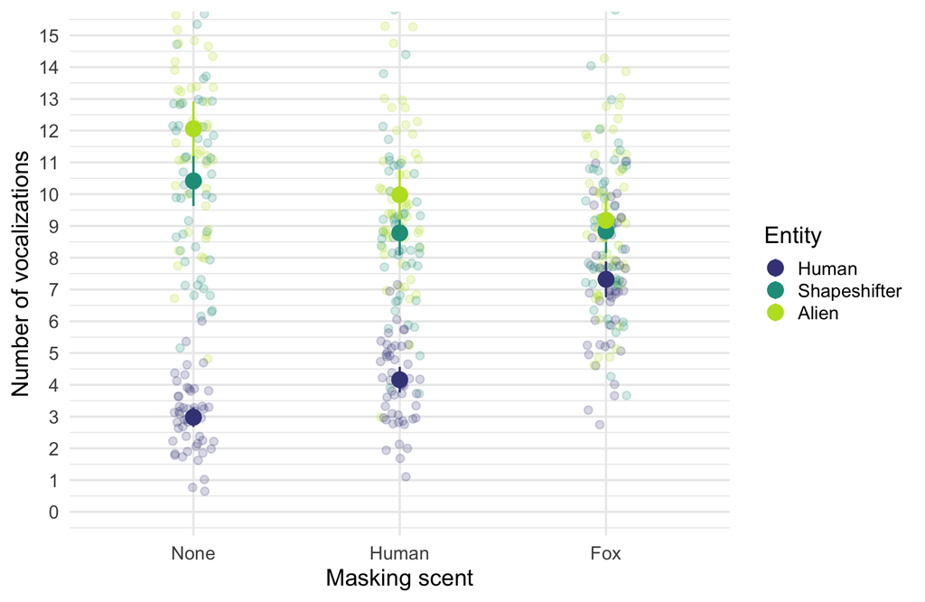

## Slide 47: Fit the model: contrasts

We have a natural control group for the entity (human) so a natural contrast is to use dummy coding.

- **Contrast 1**: {alien} vs. {human}
- **Contrast 2**: {shapeshifter} vs. {human}

We have a natural control group for the scent masks (no scent) so a natural contrast is to use dummy coding.

- **Contrast 1**: {human} vs. {none}
- **Contrast 2**: {fox} vs. {none}

## Slide 48: Specifying contrasts

The level order of the variables is:

```r
levels(scent_tib$entity)
```

```
[1] "Human"        "Shapeshifter" "Alien"
```

```r
levels(scent_tib$scent_mask)
```

```
[1] "None"  "Human" "Fox"
```

We can do nothing (default dummy coding will do the above) or set up contrasts explicitly with:

```r
contrasts(scent_tib$entity) <- contr.treatment(3, base = 1)
contrasts(scent_tib$scent_mask) <- contr.treatment(3, base = 1)
```

## Slide 49: Building models

```r
scent_base <- glmmTMB::glmmTMB(
  vocalizations ~ 1 + (1|dog_id),
  data = scent_tib)

scent_ent <- glmmTMB::glmmTMB(
  vocalizations ~ entity + (1|dog_id),
  data = scent_tib)

scent_scent <- glmmTMB::glmmTMB(
  vocalizations ~ entity + scent_mask + (1|dog_id),
  data = scent_tib)

scent_int <- glmmTMB::glmmTMB(
  vocalizations ~ entity + scent_mask + entity:scent_mask + (1|dog_id),
  data = scent_tib)
```

## Slide 50: Evaluate

```r
test_lrt(scent_base, scent_ent, scent_scent, scent_int) |>
  display()
```

Likelihood-Ratio-Test (LRT) for Model Comparison (ML-estimator)

| Name | df | df_diff | Chi2 | p |
| --- | --- | --- | --- | --- |
| scent_base | 3 |  |  |  |
| scent_ent | 5 | 2 | 327.42 | < .001 |
| scent_scent | 7 | 2 | 13.36 | 0.001 |
| scent_int | 11 | 4 | 183.79 | < .001 |

> **Warning: The danger zone!**

> **“It is never sensible to interpret main effects in the presence of a significant interaction effect.”**

## Slide 51: Evaluate

```r
model_performance(scent_int) |>
  display()
```

| AIC | AICc | BIC | R2 (cond.) | R2 (marg.) | ICC | RMSE | Sigma |
| --- | --- | --- | --- | --- | --- | --- | --- |
| 1918.9 | 1919.5 | 1964.1 | 0.76 | 0.59 | 0.41 | 1.70 | 1.78 |

## Slide 52: Evaluate assumptions

```r
check_model(scent_int)
```

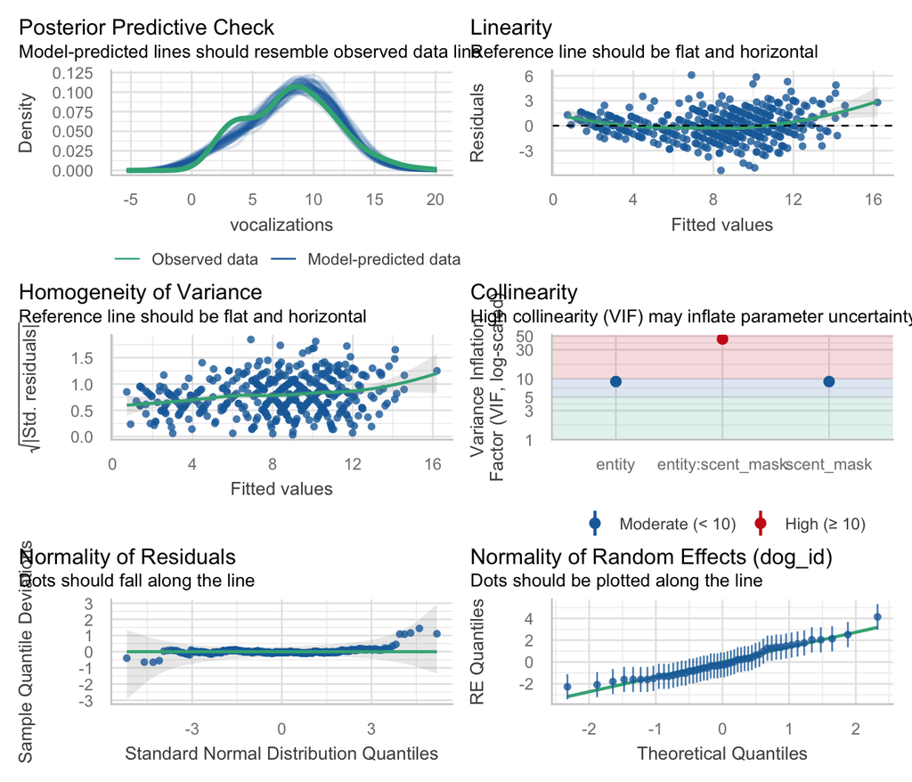

## Slide 53: Interpret: Entity × scent_mask interaction

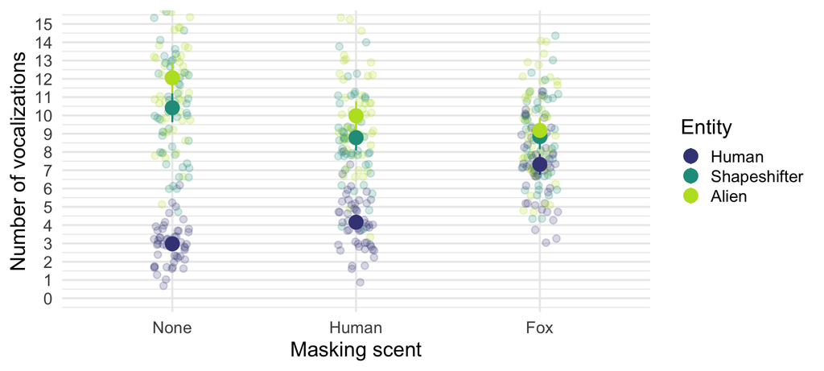

> **Important: ReportR**

> The interaction effect suggests that the effect of entity on vocalizations was significantly moderated by what scent the entity was wearing, $\chi^2$(4) = 183.79, *p* < 0.001.

## Slide 54: Interpret

```r
model_parameters(scent_int, effects = "fixed") |>
  display()
```

Fixed Effects

| Parameter | Coefficient | SE | 95% CI | z | p |
| --- | --- | --- | --- | --- | --- |
| (Intercept) | 2.98 | 0.33 | (2.34, 3.62) | 9.08 | < .001 |
| entity (Shapeshifter) | 7.44 | 0.36 | (6.74, 8.14) | 20.85 | < .001 |
| entity (Alien) | 9.08 | 0.36 | (8.38, 9.78) | 25.45 | < .001 |
| scent mask (Human) | 1.18 | 0.36 | (0.48, 1.88) | 3.31 | < .001 |
| scent mask (Fox) | 4.34 | 0.36 | (3.64, 5.04) | 12.16 | < .001 |
| entity (Shapeshifter) × scent mask (Human) | -2.82 | 0.50 | (-3.81, -1.83) | -5.59 | < .001 |
| entity (Alien) × scent mask (Human) | -3.26 | 0.50 | (-4.25, -2.27) | -6.46 | < .001 |
| entity (Shapeshifter) × scent mask (Fox) | -5.92 | 0.50 | (-6.91, -4.93) | -11.73 | < .001 |
| entity (Alien) × scent mask (Fox) | -7.22 | 0.50 | (-8.21, -6.23) | -14.31 | < .001 |

## Slide 55: Entity × scent_mask interaction: parameter 1

Fixed Effects

| Parameter | Coefficient | SE | 95% CI | z | p |
| --- | --- | --- | --- | --- | --- |
| entity (Shapeshifter) × scent mask (Human) | -2.82 | 0.50 | (-3.81, -1.83) | -5.59 | < .001 |

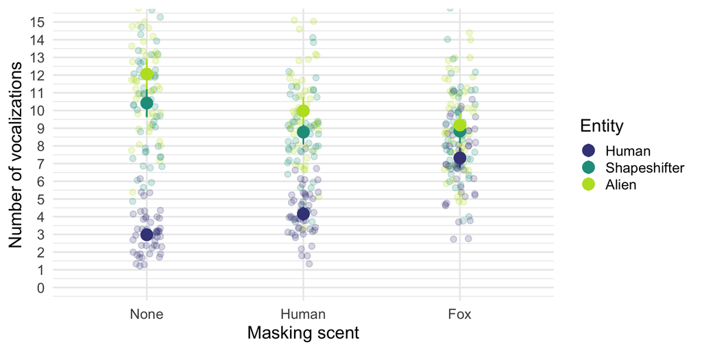

## Slide 56: Entity × scent_mask interaction: parameter 1

Fixed Effects

| Parameter | Coefficient | SE | 95% CI | z | p |
| --- | --- | --- | --- | --- | --- |
| entity (Shapeshifter) × scent mask (Human) | -2.82 | 0.50 | (-3.81, -1.83) | -5.59 | < .001 |

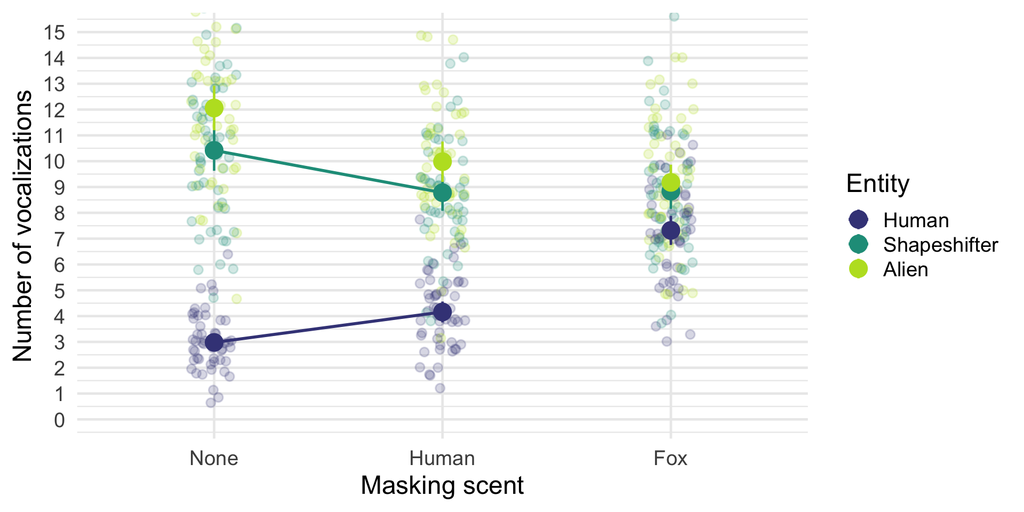

## Slide 57: Entity × scent_mask interaction: parameter 2

Fixed Effects

| Parameter | Coefficient | SE | 95% CI | z | p |
| --- | --- | --- | --- | --- | --- |
| entity (Alien) × scent mask (Human) | -3.26 | 0.50 | (-4.25, -2.27) | -6.46 | < .001 |

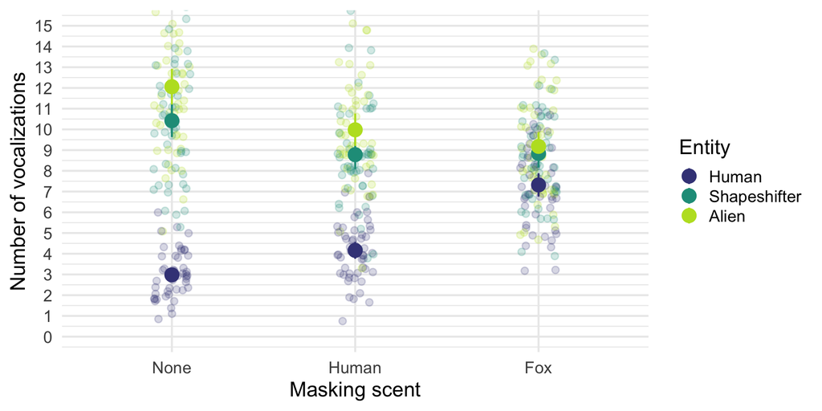

## Slide 58: Entity × scent_mask interaction: parameter 2

Fixed Effects

| Parameter | Coefficient | SE | 95% CI | z | p |
| --- | --- | --- | --- | --- | --- |
| entity (Alien) × scent mask (Human) | -3.26 | 0.50 | (-4.25, -2.27) | -6.46 | < .001 |

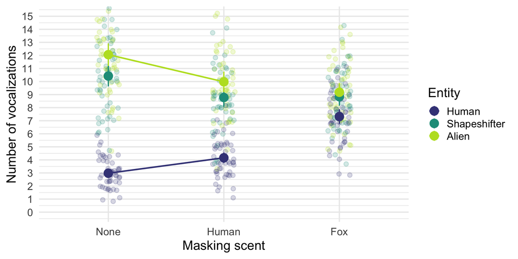

## Slide 59: Entity × scent_mask interaction: parameter 3

Fixed Effects

| Parameter | Coefficient | SE | 95% CI | z | p |
| --- | --- | --- | --- | --- | --- |
| entity (Shapeshifter) × scent mask (Fox) | -5.92 | 0.50 | (-6.91, -4.93) | -11.73 | < .001 |

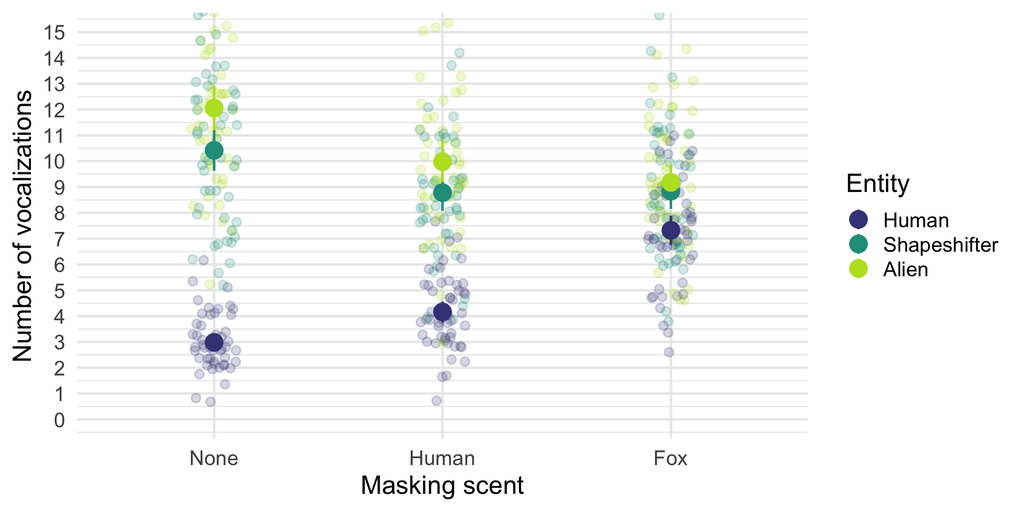

## Slide 60: Entity × scent_mask interaction: parameter 3

Fixed Effects

| Parameter | Coefficient | SE | 95% CI | z | p |
| --- | --- | --- | --- | --- | --- |
| entity (Shapeshifter) × scent mask (Fox) | -5.92 | 0.50 | (-6.91, -4.93) | -11.73 | < .001 |

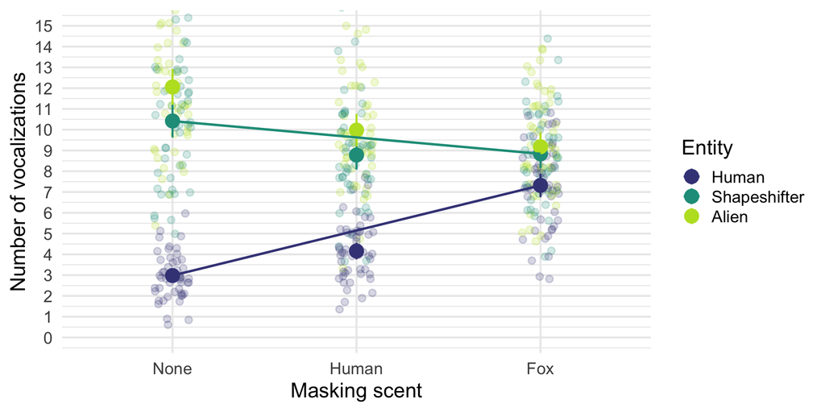

## Slide 61: Entity × scent_mask interaction: parameter 4

Fixed Effects

| Parameter | Coefficient | SE | 95% CI | z | p |
| --- | --- | --- | --- | --- | --- |
| entity (Alien) × scent mask (Fox) | -7.22 | 0.50 | (-8.21, -6.23) | -14.31 | < .001 |

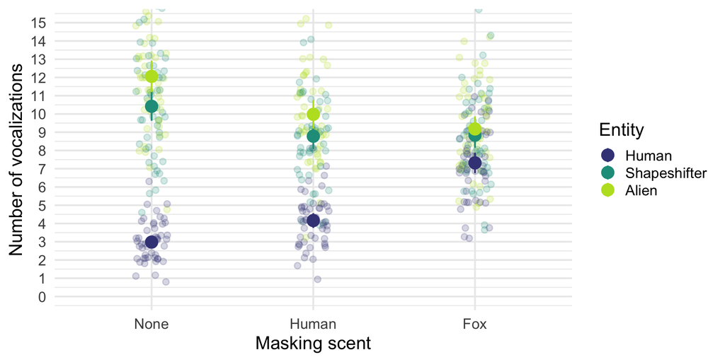

## Slide 62: Entity × scent_mask interaction: parameter 4

Fixed Effects

| Parameter | Coefficient | SE | 95% CI | z | p |
| --- | --- | --- | --- | --- | --- |
| entity (Alien) × scent mask (Fox) | -7.22 | 0.50 | (-8.21, -6.23) | -14.31 | < .001 |

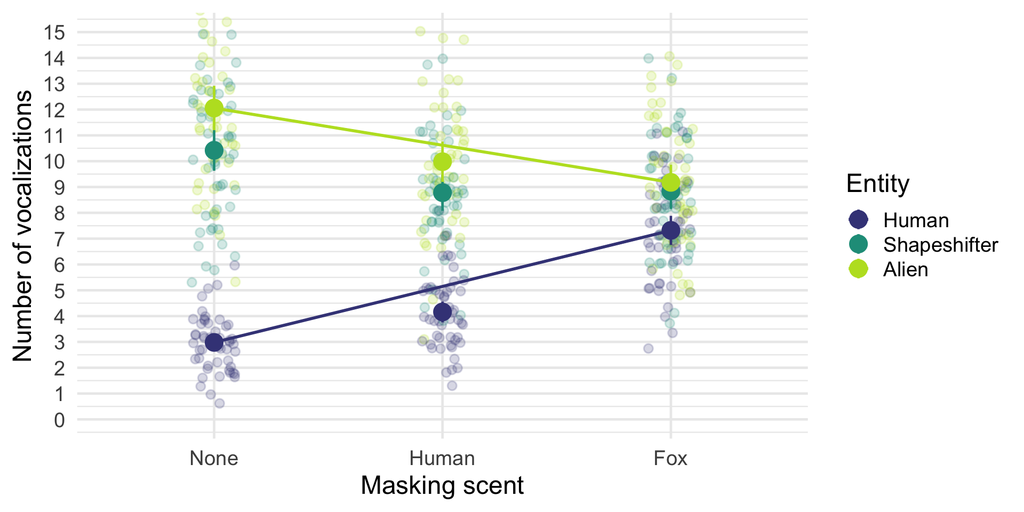

## Slide 63

Video clip: [space closing scene](https://profandyfield.github.io/statistics_lectures/shared_media/video/space_closing_scene.mp4)